# Topic 3 - Classification using KNN and logistic regression

MSDA7003 - Machine Learning

KT Wong

Faculty of Social Sciences, HKU

2024-09-27

The materials in this topic are drawn from Lantz (2023) and James et al. (2023)

# Understanding nearest neighbor classification

## Introduction

- nearest neighbor classifiers are defined by their characteristic of classifying **unlabeled examples** by assigning them to the class of **similar labeled examples**
- With nearest neighbor classification, computers apply a human-like ability
  - recall past experiences to make conclusions about current circumstances
- This strategy have been used successfully for:
  - **Computer vision applications**: optical character recognition and facial recognition in still images and video
  - **Recommendation systems**: predict whether a person will enjoy a movie or song
  - **Identifying patterns**: detect specific proteins or diseases in genetic data
  - **Anomaly detection**: identify unusual patterns in data
- nearest neighbor classifiers are well suited for classification tasks where
  - relationships among the features and the target classes are **numerous, complicated** (or simply extremely difficult to understand)
  - yet the items of similar class types tend to be fairly *homogeneous*

## The k-NN algorithm

- The most prominent case is the k-nearest neighbors algorithm (k-NN)
- it uses information about a case’s k nearest neighbors to classify “unlabeled” cases
- The general steps in its implementation are:
  1. choose $k$
  2. the algorithm requires a training dataset made up of samples that have been classified into several categories
     - often labeled by a nominal variable
  3. for each “unlabeled” record in the test dataset, k-NN identifies the $k$ records in the training data that are the “nearest” in similarity
  4. The “unlabeled” test instance is assigned the class representing the majority of the $k$ nearest neighbors

## An Example

The structure of the dataset

| Ingredient | Sweetness | Crunchiness | Food type |
| --- | --- | --- | --- |
| Apple | 10 | 9 | Fruit |
| Bacon | 1 | 4 | Protein |
| Banana | 10 | 1 | Fruit |
| Carrot | 7 | 10 | Vegetable |
| Celery | 3 | 10 | Vegetable |

- Here, we assume there are only two dimensions in feature space

## Visualizing the data

- We can display the the relationship between the sweetness and crunchiness of the ingredients from the data on a scatterplot

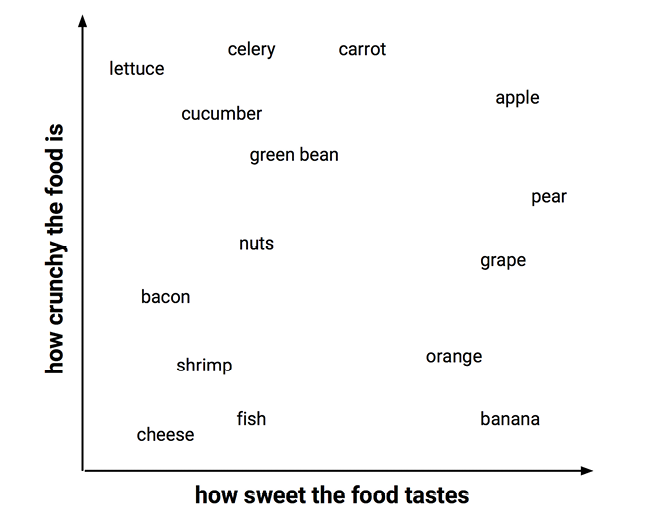

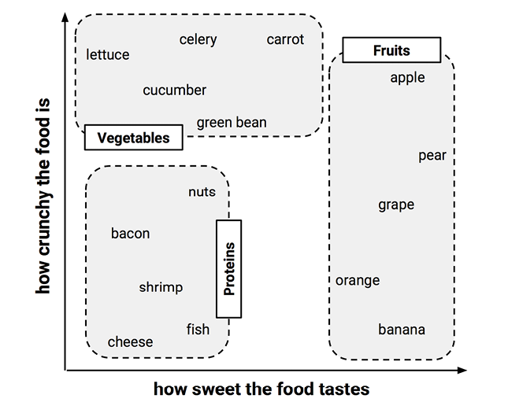

## An age-old question

- Is a tomato a fruit or a vegetable?

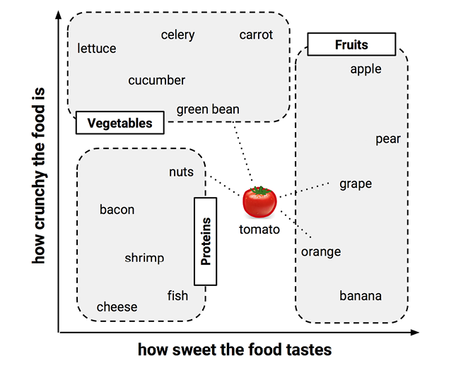

## Measuring similarity with distance

- Locating the tomato’s nearest neighbors requires a distance function
  - a formula that measures the similarity between two instances
- There are many ways to calculate distance
  - Euclidean distance
  - Manhattan distance
  - …

Distance to the tomato

| Ingredient | Sweetness | Crunchiness | Food Type | Distance to the tomato |
| --- | --- | --- | --- | --- |
| Grape | 8 | 5 | Fruit | $\sqrt{((6 - 8)^2 + (4 - 5)^2)} = 2.2$ |
| Green bean | 3 | 7 | Vegetable | $\sqrt{((6 - 3)^2 + (4 - 7)^2)} = 4.2$ |
| Nuts | 3 | 6 | Protein | $\sqrt{((6 - 3)^2 + (4 - 6)^2)} = 3.6$ |
| Orange | 7 | 3 | Fruit | $\sqrt{((6 - 7)^2 + (4 - 3)^2)} = 1.4$ |

- if using 1-NN, a tomato will be classified as a fruit
- how about using 3-NN?

## Choosing an appropriate k

- The decision of how many neighbors to use for k-NN determines how well the model will generalize to future data
- This is a classical **bias-variance tradeoff** problem
  - The balance between *overfitting* and *underfitting* the training data
- A larger k has higher bias and lower variance than a smaller $k$
- In practice, the choice of $k$ depends on the difficulty of the concept to be learned and the number of records in the training data
- One commonly suggested approach is to begin with $k$ equal to the square root of the number of training examples
  - caution: such rules may not always result in the single best $k$

## Preparing data for use with k-NN

- Features are typically transformed to a standard range prior to applying the k-NN algorithm
- the distance formula is highly dependent on how features are measured
- rescale the features by shrinking or expanding their range such that each one contributes relatively equally to the distance formula
- There are several common ways to do the rescaling
  1. **min-max normalization**
     $$X_{new}=\frac{X-min(X)}{max(X)-min(X)}$$
  2. **z-score standardization**
     $$X_{new}=\frac{X-\mu}{\sigma}$$

## Preparing data for use with k-NN

- Notice that the Euclidean distance formula is undefined for nominal features
- use dummy coding instead

$$male=\begin{cases} 1 & \text{if} \text{ x=male} \\
0 & \text{otherwise}
\end{cases}$$

- An $n$-category nominal feature can be dummy coded by creating binary indicator variables for $n - 1$ levels of the feature
- one-hot encoding creates binary features for all n levels of the feature
- uses dummy coding here even though you may encounter one-hot encoding sometime later

## What makes the k-NN algorithm distinctive

- Classification algorithms based on nearest neighbor methods are considered **lazy** learning algorithms
  - no abstraction occurs
  - the abstraction and generalization processes are skipped altogether
- Due to the heavy reliance on the **training instances** rather than an **abstract model**
  - lazy learning is also known as **instance-based learning** or **rote learning**
- the heavy reliance on the training instances (rather than an abstract model) - instance-based learning
- the method is said to be in a class of non-parametric learning methods
  - no parameters are learned about the data
- Without generating theories about the underlying data, non-parametric methods limit our ability to understand how the classifier is using the data, yet it can still make useful predictions
- Non-parametric learning allows the learner to find natural patterns rather than trying to fit the data into a preconceived and potentially biased functional form

## The strengths and weaknesses of k-NN

- Strengths
  - Simple and effective
  - Makes no assumptions about the underlying data distribution
  - Fast training phase
- Weaknesses
  - Does not produce a model, limiting the ability to understand how the features are related to the class
  - Requires selection of an appropriate $k$
  - Slow classification phase
    - Nominal features and missing data require additional processing

## Logistic regression as an alternative

- let us recap some notations to formalize the discussion
- Let $X$ be a $p$-dimensional random vector representing the features
- Let $\mathcal{C}$ be a set of $q$ classes
- Let $Y$ be a categorical response variable taking values in the set $\mathcal{C}$
- the classification task is to build a function $C(X)$
  - takes $X$ as input and predicts its value for $Y$ i.e. $Y=C(X) \in \mathcal{C}$
- The goal of logistic regression is to estimate the conditional probability

$$P(Y = c|X = x) \quad \text{for each class } c \in\mathcal{C}$$

$\quad$ where $|\mathcal{C}|=2$

## Logistic regression

- The logistic regression model is a linear model for binary classification, say 0 or 1
- The model is defined as

$$P(Y=1|X=x)=\frac{e^{\beta_0+\beta_1X_1+\ldots+\beta_pX_p}}{1+e^{\beta_0+\beta_1X_1+\ldots+\beta_pX_p}}$$

- we may write $p(x)=P(Y=1|X=x)$ for simplicity
- In social science research, researchers might write the model in the log-odds form

$$\log\left(\frac{P(Y=1|X=x)}{1-P(Y=1|X=x)}\right)=\beta_0+\beta_1X_1+\ldots+\beta_pX_p$$

- the log-odds is also known as the logit function (or logit transformation of $p(x)$)

## Logistic regression

- The model is estimated by maximizing the **likelihood function**
- The **likelihood function** is the probability of observing the data given the model parameters

$$\begin{aligned}
L(\beta_0,\beta_1,\ldots,\beta_p)&=P(Y=y_1,X=x_1) \cdot P(Y=y_2,X=x_2) \cdot \ldots \cdot P(Y=y_n,X=x_n)\\
&=\prod_{i: y_i=1}^{n}P(Y=1|X=x_i)\prod_{i: y_i=0}^{n}P(Y=0|X=x_i)
\end{aligned}$$

- The likelihood gives the probability of the observed zeros and ones in the data
- the training is to search for $\beta$s that maximize the likelihood function
- The **log-likelihood function** is the natural logarithm of the likelihood function

## Logistic regression - loan default example

- Suppose we have a dataset of loan applicants
- The response variable is binary: 1 for default and 0 for non-default
- The features include the applicant’s income, student status, and balance amount
- The logistic regression model estimates the probability of default given the applicant’s features
- The model could then be used to predict the probability of default for new applicants

```
spc_tbl_ [10,000 × 4] (S3: spec_tbl_df/tbl_df/tbl/data.frame)
 $ default: chr [1:10000] "No" "No" "No" "No" ...
 $ student: chr [1:10000] "No" "Yes" "No" "No" ...
 $ balance: num [1:10000] 730 817 1074 529 786 ...
 $ income : num [1:10000] 44362 12106 31767 35704 38463 ...
 - attr(*, "spec")=
  .. cols(
  ..   default = col_character(),
  ..   student = col_character(),
  ..   balance = col_double(),
  ..   income = col_double()
  .. )
 - attr(*, "problems")=<externalptr>
```

## Logistic regression - loan default example

- for illustration, we will use the balance feature to predict the probability of default

```
Call:
glm(formula = default1 ~ balance, family = "binomial", data = default)

Coefficients:
              Estimate Std. Error z value Pr(>|z|)
(Intercept) -1.065e+01  3.612e-01  -29.49   <2e-16 ***
balance      5.499e-03  2.204e-04   24.95   <2e-16 ***
---
Signif. codes:  0 '***' 0.001 '**' 0.01 '*' 0.05 '.' 0.1 ' ' 1

(Dispersion parameter for binomial family taken to be 1)

    Null deviance: 2920.6  on 9999  degrees of freedom
Residual deviance: 1596.5  on 9998  degrees of freedom
AIC: 1600.5

Number of Fisher Scoring iterations: 8
```

- The estimated probability of default for an applicant with a balance of 1000 is

```
          1
0.005752145
```

$$\hat{p}(X)=\frac{e^{-10.65+0.0055X}}{1+e^{-10.65+0.0055X}}=0.00575$$

- The estimated probability of default for an applicant with a balance of 2000 is

```
        1
0.5857694
```

## Logistic regression - loan default example

- let us visualize the estimated probability of default for different values of the balance

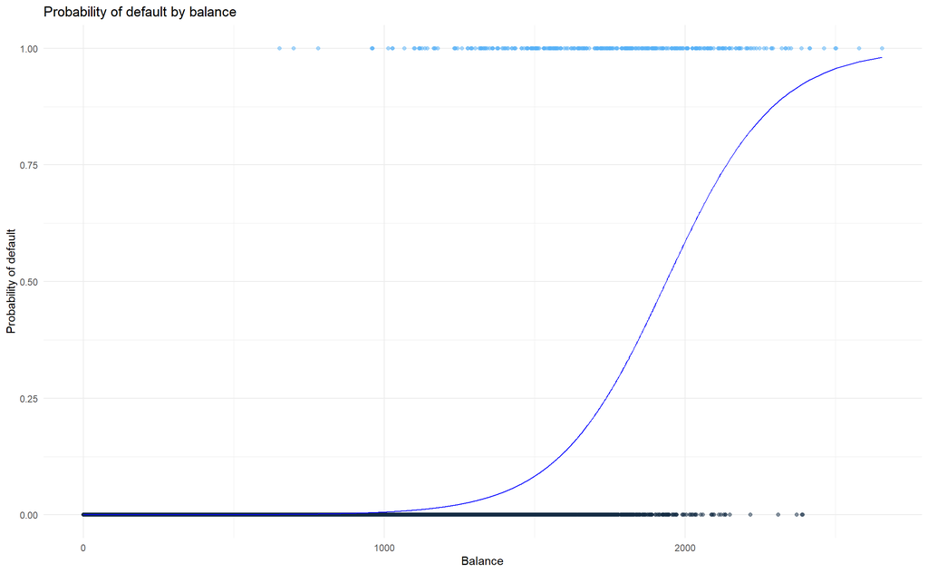

## Logistic regression - loan default example

- let us use Student status as a predictor

|  | default 1 |  |
| --- | --- | --- |
| Predictors | Log-Odds | p |
| (Intercept) | -3.5041 | **<0.001** |
| student [Yes] | 0.4049 | **<0.001** |
| Observations | 10000 |  |

$$\hat{p}(X)=\frac{e^{-3.5+0.4041X}}{1+e^{-3.5+0.4041X}}$$

if student

```
         1
0.04313859
```

$$\hat{p}(X)=\frac{e^{-3.5+0.4041}}{1+e^{-3.5+0.4041}}=0.04$$

if not student

```
         1
0.02919501
```

$$\hat{p}(X)=\frac{e^{-3.5}}{1+e^{-3.5}}=0.03$$

## Logistic regression - loan default example

- Full model

|  | default 1 |  |
| --- | --- | --- |
| Predictors | Log-Odds | p |
| (Intercept) | -10.8690 | **<0.001** |
| balance | 0.0057 | **<0.001** |
| income | 0.0000 | 0.712 |
| student [Yes] | -0.6468 | **0.006** |
| Observations | 10000 |  |

- let us visualize the estimated probability of default for different values of the student status

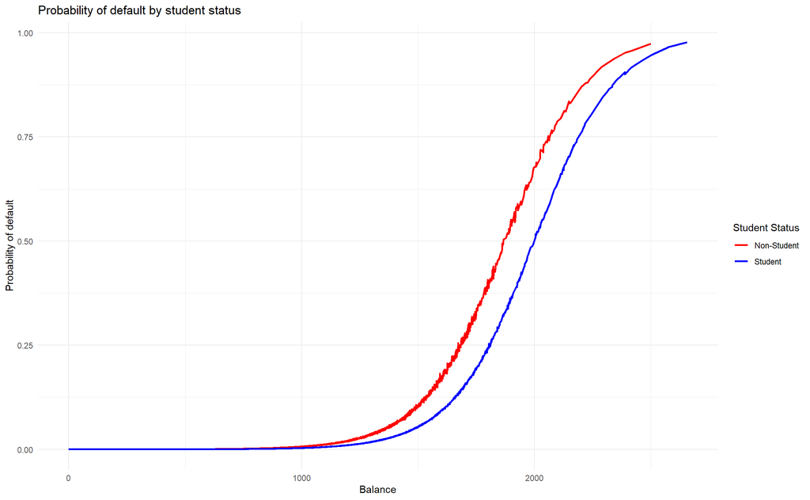

## Logistic regression - loan default example

- let us visualize the credit card balance for different student status

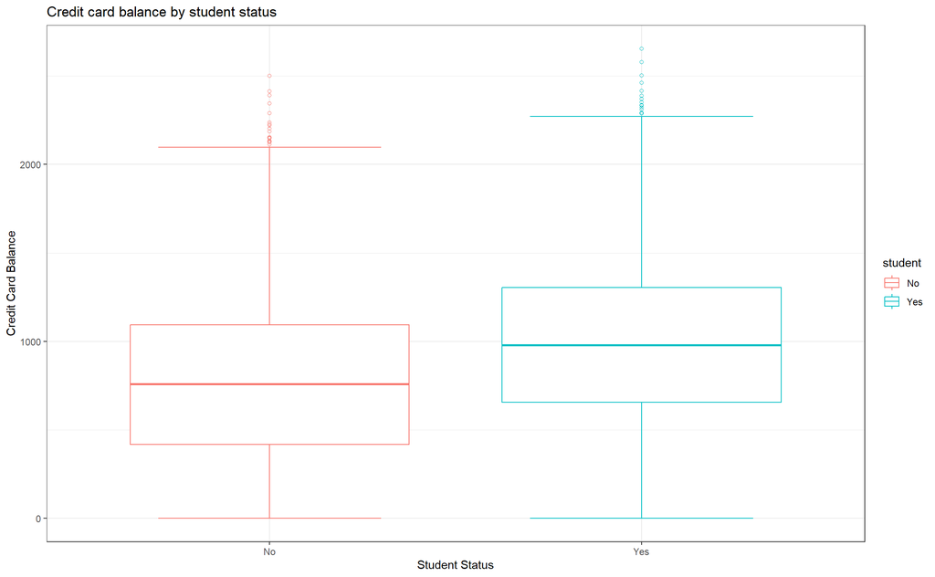

## Logistic regression with more than two classes

- The logistic regression model can be extended to handle more than two classes, say $q>2$ classes
- The **multinomial logistic regression** model estimates the conditional probability of each class given the features
- The model is defined as:

$$P(Y=c|X=x)=\frac{e^{\beta_{c0}+\beta_{c1}X_1+\ldots+\beta_{cp}X_p}}{\sum_{c=1}^{q}e^{\beta_{c0}+\beta_{c1}X_1+\ldots+\beta_{cp}X_p}}$$

$\quad$ for $c=1,2,\ldots,q$

- The model is estimated by maximizing the likelihood function
- Multi-class logistic regression is refered to as multinomial regression
- it can be implemented in R using glmnet package with family = “multinomial”
- we will not cover the details here

## References

James, G., D. Witten, T. Hastie, and R. Tibshirani. 2023. *An Introduction to Statistical Learning with Applications in r*. Second edition. Springer.

Lantz, Brett. 2023. *Machine Learning with r : Learn Techniques for Building and Improving Machine Learning Models, from Data Preparation to Model Tuning, Evaluation, and Working with Big Data*. Fourth edition. Expert Insight. Birmingham, UK: Packt Publishing Limited.